# Identifying key species habitats and corridors"

Lukmann Haqeem

26 September, 2022

## Getting started

```r
# Load packages
library(unmarked)
library(jagsUI)
library(raster)
library(gdistance)
library(cluster)
library(factoextra)

# Load data sets
#load sample data
set.seed(1234)
dat <- read.csv(file.choose(), comment = "#")
head(dat)
```

```
##   northing easting occ1 occ2 occ3 elevation forest
## 1    57276 1127942    0    0    0       420      3
## 2   215276 1037942    0    0    0      1050     32
## 3    43276 1140942    0    0    0      1110     35
## 4    71276  928942    0    0    0       510      2
## 5   214276 1130942    0    0    0       530     13
## 6   221276 1163942    2    1    0      1140     50
```

```r
dim(dat)
```

```
## [1] 92  7
```

```r
#load study area (for predictions part later)
data(Switzerland)
head(Switzerland)
```

```
##        x     y elevation forest water
## 1 910942 54276       340      6     0
## 2 910942 55276       340     11     1
## 3 911942 54276       380      4     0
## 4 911942 55276       390     72     3
## 5 911942 56276       357      9     7
## 6 911942 57276       357      5     5
```

```r
dim(Switzerland)
```

```
## [1] 42275     5
```

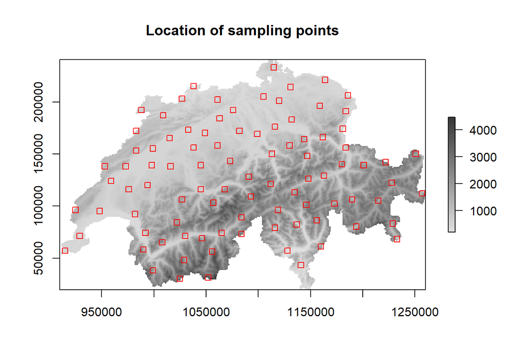

```r
# Plot data sets
#study area
raster <- rasterFromXYZ(data.frame(x = Switzerland$x,
                                   y = Switzerland$y,
                                   z = Switzerland$elevation))
mapPalette <- colorRampPalette(c("grey88", "grey66", "grey44", "grey22"))
plot(raster, col = mapPalette(100), main = "Location of sampling points")
#sampling points
points(dat$easting, dat$northing, pch = 0, cex = 1, col = "red")
```

```r
# Perform EDA
#extract the count data
C <- as.matrix(dat[,3:5])
#check initial patterns or anomalies
head(C)
```

```
##      occ1 occ2 occ3
## [1,]    0    0    0
## [2,]    0    0    0
## [3,]    0    0    0
## [4,]    0    0    0
## [5,]    0    0    0
## [6,]    2    1    0
```

```r
Cmax <- apply(C, 1, max, na.rm = TRUE)
min(Cmax)
```

```
## [1] 0
```

```r
max(Cmax)
```

```
## [1] 12
```

```r
nSites <- nrow(C)
nOcc <- rowSums(!is.na(C))
```

## Statistical modeling

```r
# Run Bayesian N-mixture model
#construct JAGS building block for state-space model
modelText <- "
model{
for(i in 1:nSites){
    # Likelihood
    log(lambda[i]) <- b0 +
                      bForest * forest[i] +
                      bForest2 * forest2[i] +
                      bElevation * elevation[i] +
                      bElevation2 * elevation2[i]
    # Ecological process
    N[i] ~ dpois(lambda[i])

    for (j in 1:nOcc[i]){
        # Observation process
        C[i,j] ~ dbin(p, N[i])
    }
}
    # Priors
    b0 ~ dunif(-10, 10)
    bForest ~ dunif(-5, 5)
    bForest2 ~ dunif(-5, 5)
    bElevation ~ dunif(-5, 5)
    bElevation2 ~ dunif(-5, 5)
    p ~ dunif(0, 1)
}
 "
writeLines(modelText, "model1.jags")
#organise data sets for the model
jagsData <- list(nSites = nrow(C),
                 nOcc = nOcc,
                 C = C,
                 forest = dat$forest,
                 forest2 = dat$forest^2,
                 elevation = dat$elevation,
                 elevation2 = dat$elevation^2)
str(jagsData)
```

```
## List of 7
##  $ nSites    : int 92
##  $ nOcc      : num [1:92] 3 3 3 3 3 3 3 3 3 3 ...
##  $ C         : int [1:92, 1:3] 0 0 0 0 0 2 0 0 2 0 ...
##   ..- attr(*, "dimnames")=List of 2
##   .. ..$ : NULL
##   .. ..$ : chr [1:3] "occ1" "occ2" "occ3"
##  $ forest    : int [1:92] 3 32 35 2 13 50 57 84 66 45 ...
##  $ forest2   : num [1:92] 9 1024 1225 4 169 ...
##  $ elevation : int [1:92] 420 1050 1110 510 530 1140 770 1220 1270 380 ...
##  $ elevation2: num [1:92] 176400 1102500 1232100 260100 280900 ...
```

```r
#set parameters to monitor
monitor <- c("b0", "bForest", "bForest2", "bElevation", "bElevation2")
#set initial values for parameters
init <- function() list(N = Cmax, z = rep(1, nrow(C)))
#run the model
system.time(
    sim1 <- jags(data = jagsData,
                 inits = init,
                 parameters.to.save = monitor,
                 model.file = "model1.jags",
                 n.chains = 3,
                 n.iter = 30000,
                 n.burn = ni/2,
                 n.adapt = 1000,
                 parallel = TRUE,
                 DIC = FALSE)
) # 22 s
```

```
##
## Processing function input.......
##
## Done.
##
## Beginning parallel processing using 3 cores. Console output will be suppressed.
##
## Parallel processing completed.
##
## Calculating statistics.......
##
## Done.
```

```
##    user  system elapsed
##    0.06    0.07   17.90
```

```r
#check for chains convergence
mean(unlist(sim1$Rhat) > 1.1)
```

```
## [1] 0
```

## Making prediction

```r
# Using the model for making predictions across the entire study area (~SDM)
#estimate 1000 abundance estimates for the entire study area
tmp <- matrix(NA, nrow = n, ncol = nrow(Switzerland))
n <- 1000
ord <- sample(1:length(sim1$sims.list$b0), n, replace = FALSE)
system.time(
    for(i in 1:n){
        for(j in 1:nrow(Switzerland)){
        tmp[i,j] <- exp(sim1$sims.list$b0[ord[i]] +
                        sim1$sims.list$bForest[ord[i]]*Switzerland$forest[j] +
                        sim1$sims.list$bForest2[ord[i]]*Switzerland$forest[j]^2 +
                        sim1$sims.list$bElevation[ord[i]]*Switzerland$elevation[j] +
                        sim1$sims.list$bElevation2[ord[i]]*Switzerland$elevation[j]^2)
        }
    }
) # 256 sec
#save(tmp, file = "1000AbundanceLayers.RData")
```

```r
# Estimate optimal number of clusters
#load prediction
load(file = "1000AbundanceLayers.RData")
dim(tmp)
```

```
## [1]  1000 42275
```

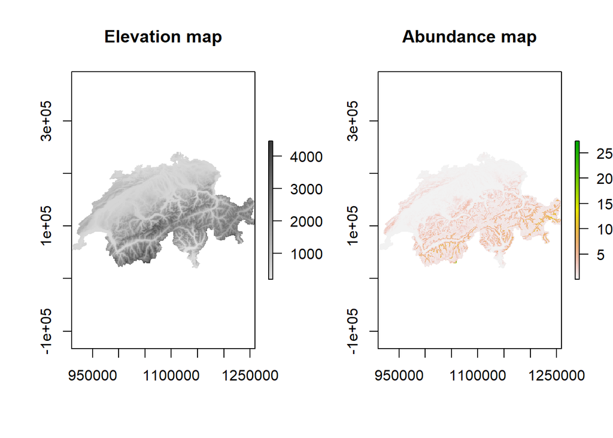

```r
#compare elevation and species abundance maps
Switzerland$abundance <- colMeans(tmp)
raster_abundance <- rasterFromXYZ(data.frame(x = Switzerland$x, y = Switzerland$y, z = Switzerland$abundance))
par(mfrow = c(1, 2))
plot(raster, col = mapPalette(100), main = "Elevation map")
plot(raster_abundance, main = "Abundance map")
```

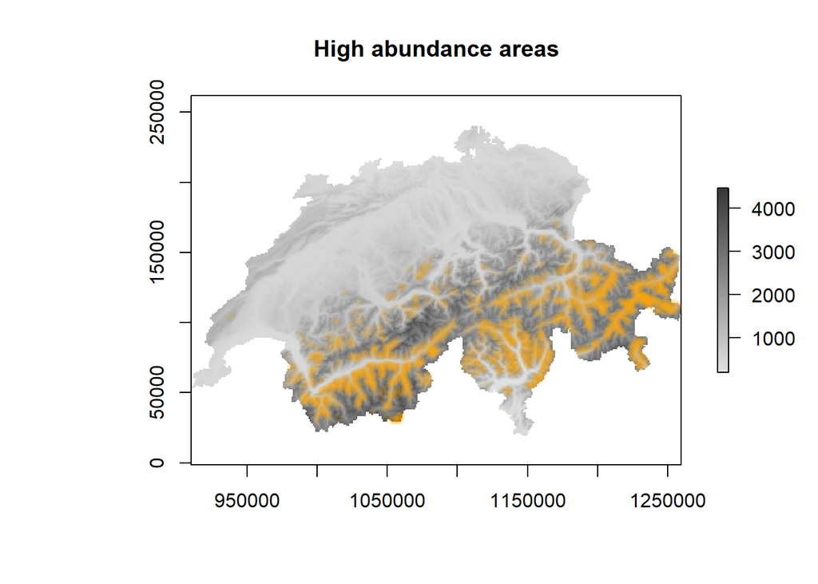

```r
par(mfrow = c(1, 1))

#'identify' key areas
high_abundance <- Switzerland[Switzerland$abundance > 4.5,] # say, greater than or equal to this is considered high species abundance
raster <- rasterFromXYZ(data.frame(x = Switzerland$x, y = Switzerland$y, z = Switzerland$elevation))
plot(raster, col = mapPalette(100), main = "High abundance areas")
points(high_abundance$x, high_abundance$y, pch = 16, cex = 1, col = adjustcolor("orange", 0.1))
```

```r
#calculate optimal number of clusters and centroids
#calculate k-means clusters
system.time(
    gap_stat <- clusGap(high_abundance, FUN = kmeans, nstart = 25, K.max = 10, B = 100, iter.max = 50)
) # 85 s
```

```
## Clustering k = 1,2,..., K.max (= 10): .. done
## Bootstrapping, b = 1,2,..., B (= 100)  [one "." per sample]:
## .................................................. 50
## .................................................. 100
```

```
##    user  system elapsed
##   66.14    0.51   67.60
```

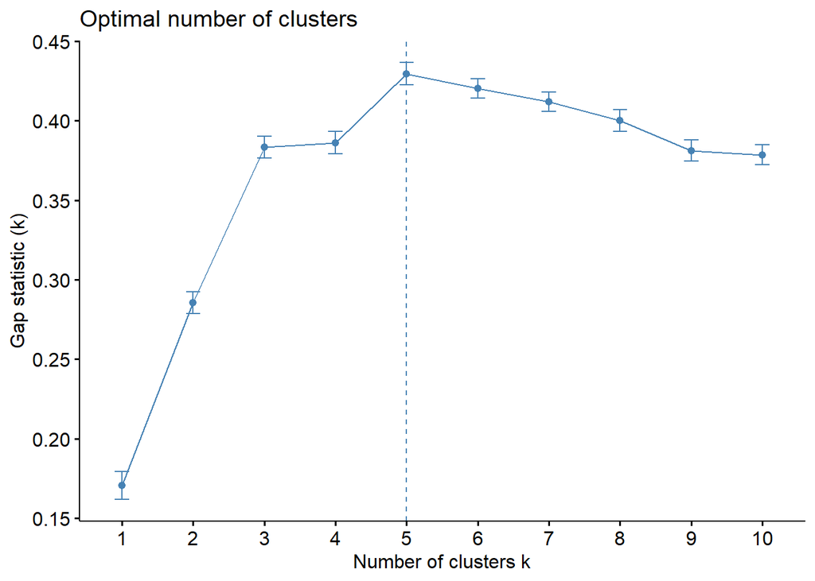

```r
fviz_gap_stat(gap_stat)
```

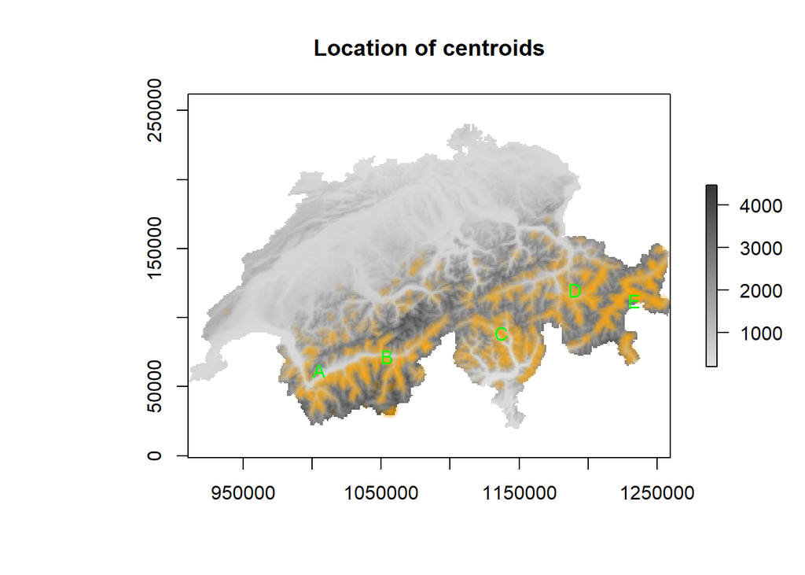

```r
#calculate centroids
A <- matrix(NA, nrow = length(high_abundance$x), ncol = 2)
A[,1] <- high_abundance$x
A[,2] <- high_abundance$y
distance <- 119500  # adjust until n. centroids = optimal n. clusters
chc <- hclust(dist(data.frame(x = high_abundance$x, y = high_abundance$y)), method = "complete")
chcd <- cutree(chc, h = distance)
centroids <- aggregate(A, list(cluster = chcd), mean)
pts <- cbind(x = centroids[,2], y = centroids[,3])
plot(raster, col = mapPalette(100), main = "Location of centroids")
points(high_abundance$x, high_abundance$y, pch = 16, cex = 1, col = adjustcolor("orange", 0.1))
text(pts[,1], pts[,2], label = LETTERS[1:nrow(pts)], col = "green")
```

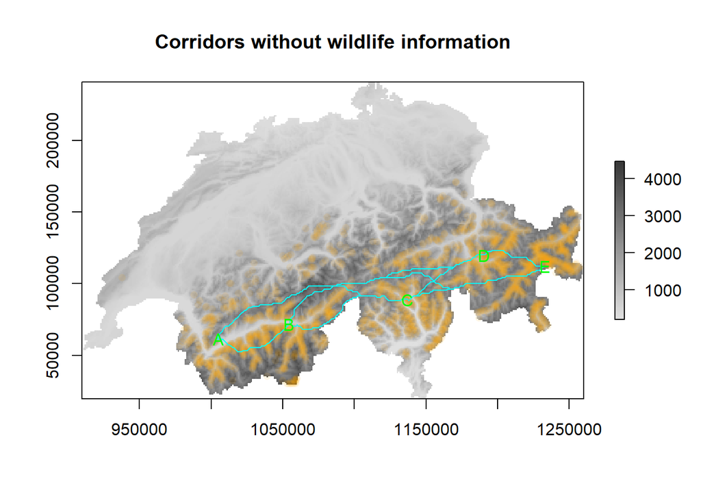

```r
# Aligning corridors on the map
#align corridors with elevation information only
plot(raster, col = mapPalette(100), main = "Corridors without wildlife information")
raster2 <- rasterFromXYZ(data.frame(x = Switzerland$x,
                                   y = Switzerland$y,
                                   z = Switzerland$elevation))
f <- function(x) max(x) - x[1] + x[2]
tr <- transition(raster2, transitionFunction = f, directions = 8)
slope <- geoCorrection(tr, type = "c", multpl = FALSE, scl = FALSE)
points(high_abundance$x, high_abundance$y, pch = 16, cex = 1, col = adjustcolor("orange", 0.1))
for(j in 1:nrow(centroids)){
    for(k in 1:nrow(centroids)){
        plot(shortestPath(slope, pts[j,], pts[k,], output = "SpatialLines"),
             col = adjustcolor("cyan", 1), lwd = 1, add = TRUE)
    }
}
text(pts[,1], pts[,2], label = LETTERS[1:nrow(pts)], col = "green")
```

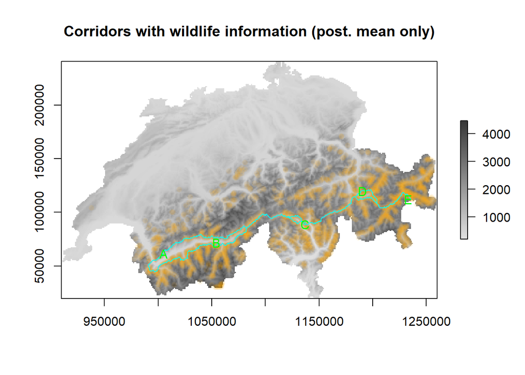

```r
#align corridors with abundance estimate (only posterior mean)
plot(raster, col = mapPalette(100), main = "Corridors with wildlife information (post. mean only)")
raster3 <- rasterFromXYZ(data.frame(x = Switzerland$x,
                                   y = Switzerland$y,
                                   z = Switzerland$abundance))
tr <- transition(raster3, transitionFunction = f, directions = 8)
slope <- geoCorrection(tr, type = "c", multpl = FALSE, scl = FALSE)
points(high_abundance$x, high_abundance$y, pch = 16, cex = 1, col = adjustcolor("orange", 0.1))
for(j in 1:nrow(centroids)){
    for(k in 1:nrow(centroids)){
        plot(shortestPath(slope, pts[j,], pts[k,], output = "SpatialLines"),
             col = adjustcolor("cyan", 1), lwd = 1, add = TRUE)
    }
}
text(pts[,1], pts[,2], label = LETTERS[1:nrow(pts)], col = "green")
```

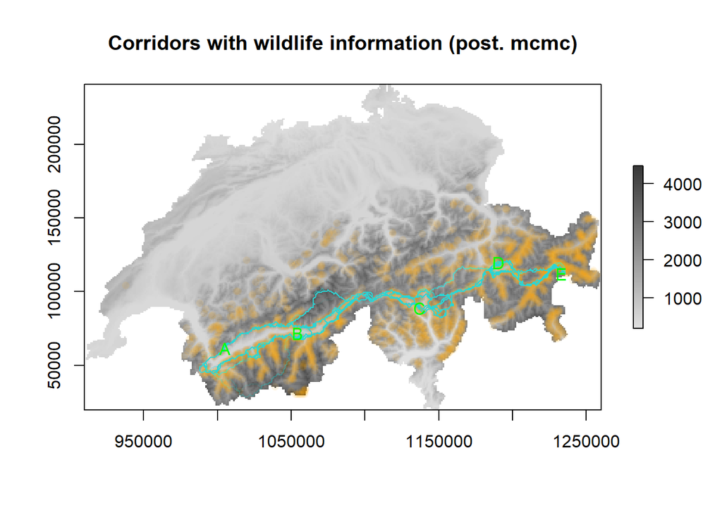

```r
#align corridors with abundance estimates (posterior MCMC)
plot(raster, col = mapPalette(100), main = "Corridors with wildlife information (post. mcmc)")
points(high_abundance$x, high_abundance$y, pch = 16, cex = 1, col = adjustcolor("orange", 0.1))
for(i in 1:n){
    #stitch the pixels into a raster
    raster4 <- rasterFromXYZ(data.frame(x = Switzerland$x, y = Switzerland$y, z = tmp[i,]))
    #calculate paths connecting all centroids
    tr <- transition(raster4, transitionFunction = f, directions = 8)
    slope <- geoCorrection(tr, type = "c", multpl = FALSE, scl = FALSE)
    for(j in 1:nrow(centroids)){
        for(k in 1:nrow(centroids)){
            plot(shortestPath(slope, pts[j,], pts[k,], output = "SpatialLines"),
                 col = adjustcolor("cyan", 0.01), lwd = 1, add = TRUE)
        }
    }
}
text(pts[,1], pts[,2], label = LETTERS[1:nrow(pts)], col = "green")
```

## Notes

- swath of lines

When selecting proper alignment, corridor designers should examine a series of lines and evaluate the advantages and disadvantages of moving to the following cells rather than solely relying on the least-cost alignment. This is because a least-cost corridor could be surrounded by otherwise inappropriate habitats (e.g. human settlements) that are unlikely to be used and would be biologically irrelevant. By incorporating the Bayesian method into this Least-Cost-Path analysis, it gives not only the least-cost alignment (shown in magenta) but other alignments (shown in cyan) as well. The latter can serve as alternatives should any parts of the least-cost alignment cannot be used – the more progressively vivid cyan indicating the more preferred alignment to choose from.

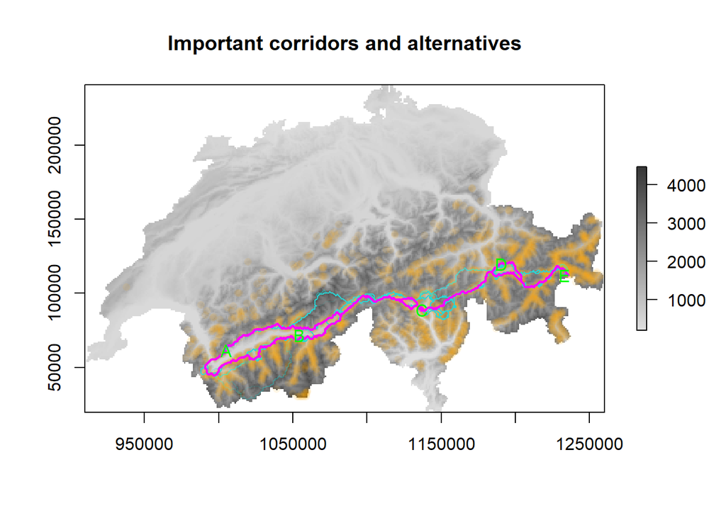

- anthropogenic resistance

Corridors often follow paths of least resistance based on the relationship between species movement and features such as terrain, land cover, or bioclimatic factors. Yet beyond the biophysical landscape, we also know that human activity can influence species movement. What has not considered in this analysis was the human activity context. Nevertheless, framing it as “anthropogenic resistance” is also possible in the modeling, and attributes such as human population densities and proximity from human infrastructures could be added to the resistance surface.